# Risk Factor Analysis

## Outcome Variable

**Outcome Variable:** sstunted

## Predictor Variables

**Intervention Variable:** tr

**Adjustment Set:**

unadjusted

## Stratifying Variables

The analysis was stratified on these variable(s):

- agecat
- studyid
- country
- intXenwast

## Data Summary

| agecat | studyid | country | intXenwast | sstunted | n_cell | n |
| --- | --- | --- | --- | --- | --- | --- |
| Birth | ki1000125-AgaKhanUniv | PAKISTAN | 0_Birth | 0 | 7 | 7 |
| Birth | ki1000125-AgaKhanUniv | PAKISTAN | 0_Birth | 1 | 0 | 7 |
| Birth | ki1000125-AgaKhanUniv | PAKISTAN | 1_Birth | 0 | 4 | 4 |
| Birth | ki1000125-AgaKhanUniv | PAKISTAN | 1_Birth | 1 | 0 | 4 |
| Birth | ki1000304b-SAS-CompFeed | INDIA | 0_Birth | 0 | 116 | 116 |
| Birth | ki1000304b-SAS-CompFeed | INDIA | 0_Birth | 1 | 0 | 116 |
| Birth | ki1000304b-SAS-CompFeed | INDIA | 1_Birth | 0 | 9 | 9 |
| Birth | ki1000304b-SAS-CompFeed | INDIA | 1_Birth | 1 | 0 | 9 |
| Birth | ki1119695-PROBIT | BELARUS | 0_Birth | 0 | 10936 | 10936 |
| Birth | ki1119695-PROBIT | BELARUS | 0_Birth | 1 | 0 | 10936 |
| Birth | ki1119695-PROBIT | BELARUS | 1_Birth | 0 | 2941 | 2941 |
| Birth | ki1119695-PROBIT | BELARUS | 1_Birth | 1 | 0 | 2941 |
| Birth | ki1126311-ZVITAMBO | ZIMBABWE | 0_Birth | 0 | 10856 | 10856 |
| Birth | ki1126311-ZVITAMBO | ZIMBABWE | 0_Birth | 1 | 0 | 10856 |
| Birth | ki1126311-ZVITAMBO | ZIMBABWE | 1_Birth | 0 | 2236 | 2236 |
| Birth | ki1126311-ZVITAMBO | ZIMBABWE | 1_Birth | 1 | 0 | 2236 |
| Birth | ki1135781-COHORTS | GUATEMALA | 0_Birth | 0 | 564 | 564 |
| Birth | ki1135781-COHORTS | GUATEMALA | 0_Birth | 1 | 0 | 564 |
| Birth | ki1135781-COHORTS | GUATEMALA | 1_Birth | 0 | 198 | 198 |
| Birth | ki1135781-COHORTS | GUATEMALA | 1_Birth | 1 | 0 | 198 |
| Birth | kiGH5241-JiVitA-3 | BANGLADESH | 0_Birth | 0 | 28406 | 28406 |
| Birth | kiGH5241-JiVitA-3 | BANGLADESH | 0_Birth | 1 | 0 | 28406 |
| Birth | kiGH5241-JiVitA-3 | BANGLADESH | 1_Birth | 0 | 3084 | 3084 |
| Birth | kiGH5241-JiVitA-3 | BANGLADESH | 1_Birth | 1 | 0 | 3084 |
| Birth | kiGH5241-JiVitA-4 | BANGLADESH | 0_Birth | 0 | 1294 | 1294 |
| Birth | kiGH5241-JiVitA-4 | BANGLADESH | 0_Birth | 1 | 0 | 1294 |
| Birth | kiGH5241-JiVitA-4 | BANGLADESH | 1_Birth | 0 | 72 | 72 |
| Birth | kiGH5241-JiVitA-4 | BANGLADESH | 1_Birth | 1 | 0 | 72 |
| 6 months | iLiNS_DYADM_LNS | MALAWI | 0_6 months | 0 | 612 | 640 |
| 6 months | iLiNS_DYADM_LNS | MALAWI | 0_6 months | 1 | 28 | 640 |

[output cut: 164 more lines]

The following strata were considered:

- agecat: 24 months, studyid: iLiNS_DYADM_LNS, country: MALAWI, intXenwast: 0_24 months
- agecat: 24 months, studyid: iLiNS_DYADM_LNS, country: MALAWI, intXenwast: 1_24 months
- agecat: 24 months, studyid: ki1000107-Serrinha-VitA, country: BRAZIL, intXenwast: 0_24 months
- agecat: 24 months, studyid: ki1000107-Serrinha-VitA, country: BRAZIL, intXenwast: 1_24 months
- agecat: 24 months, studyid: ki1000110-WASH-Bangladesh, country: BANGLADESH, intXenwast: 0_24 months
- agecat: 24 months, studyid: ki1000110-WASH-Bangladesh, country: BANGLADESH, intXenwast: 1_24 months
- agecat: 24 months, studyid: ki1000111-WASH-Kenya, country: KENYA, intXenwast: 0_24 months
- agecat: 24 months, studyid: ki1000111-WASH-Kenya, country: KENYA, intXenwast: 1_24 months
- agecat: 24 months, studyid: ki1000125-AgaKhanUniv, country: PAKISTAN, intXenwast: 0_24 months
- agecat: 24 months, studyid: ki1000304-EU, country: INDIA, intXenwast: 0_24 months
- agecat: 24 months, studyid: ki1000304-EU, country: INDIA, intXenwast: 1_24 months
- agecat: 24 months, studyid: ki1000304-Vitamin-B12, country: INDIA, intXenwast: 0_24 months
- agecat: 24 months, studyid: ki1000304-Vitamin-B12, country: INDIA, intXenwast: 1_24 months
- agecat: 24 months, studyid: ki1000304-ZnMort, country: INDIA, intXenwast: 0_24 months
- agecat: 24 months, studyid: ki1000304-ZnMort, country: INDIA, intXenwast: 1_24 months
- agecat: 24 months, studyid: ki1017093b-PROVIDE, country: BANGLADESH, intXenwast: 0_24 months
- agecat: 24 months, studyid: ki1017093b-PROVIDE, country: BANGLADESH, intXenwast: 1_24 months
- agecat: 24 months, studyid: ki1066203-TanzaniaChild2, country: TANZANIA, UNITED REPUBLIC OF, intXenwast: 0_24 months
- agecat: 24 months, studyid: ki1066203-TanzaniaChild2, country: TANZANIA, UNITED REPUBLIC OF, intXenwast: 1_24 months
- agecat: 24 months, studyid: ki1112895-Burkina Faso Zn, country: BURKINA FASO, intXenwast: 0_24 months
- agecat: 24 months, studyid: ki1112895-Burkina Faso Zn, country: BURKINA FASO, intXenwast: 1_24 months
- agecat: 24 months, studyid: ki1119695-PROBIT, country: BELARUS, intXenwast: 0_24 months
- agecat: 24 months, studyid: ki1119695-PROBIT, country: BELARUS, intXenwast: 1_24 months
- agecat: 24 months, studyid: ki1126311-ZVITAMBO, country: ZIMBABWE, intXenwast: 0_24 months
- agecat: 24 months, studyid: ki1126311-ZVITAMBO, country: ZIMBABWE, intXenwast: 1_24 months
- agecat: 24 months, studyid: ki1135781-COHORTS, country: GUATEMALA, intXenwast: 0_24 months
- agecat: 24 months, studyid: ki1135781-COHORTS, country: GUATEMALA, intXenwast: 1_24 months
- agecat: 24 months, studyid: ki1148112-iLiNS-DOSE, country: MALAWI, intXenwast: 0_24 months
- agecat: 24 months, studyid: ki1148112-iLiNS-DOSE, country: MALAWI, intXenwast: 1_24 months
- agecat: 24 months, studyid: ki1148112-iLiNS-DYAD-M, country: MALAWI, intXenwast: 0_24 months
- agecat: 24 months, studyid: ki1148112-iLiNS-DYAD-M, country: MALAWI, intXenwast: 1_24 months
- agecat: 24 months, studyid: ki1148112-LCNI-5, country: MALAWI, intXenwast: 0_24 months
- agecat: 24 months, studyid: ki1148112-LCNI-5, country: MALAWI, intXenwast: 1_24 months
- agecat: 24 months, studyid: kiGH5241-JiVitA-3, country: BANGLADESH, intXenwast: 0_24 months
- agecat: 24 months, studyid: kiGH5241-JiVitA-3, country: BANGLADESH, intXenwast: 1_24 months
- agecat: 24 months, studyid: kiGH5241-JiVitA-4, country: BANGLADESH, intXenwast: 0_24 months
- agecat: 24 months, studyid: kiGH5241-JiVitA-4, country: BANGLADESH, intXenwast: 1_24 months
- agecat: 6 months, studyid: iLiNS_DYADM_LNS, country: MALAWI, intXenwast: 0_6 months
- agecat: 6 months, studyid: iLiNS_DYADM_LNS, country: MALAWI, intXenwast: 1_6 months
- agecat: 6 months, studyid: ki1000107-Serrinha-VitA, country: BRAZIL, intXenwast: 0_6 months
- agecat: 6 months, studyid: ki1000107-Serrinha-VitA, country: BRAZIL, intXenwast: 1_6 months
- agecat: 6 months, studyid: ki1000110-WASH-Bangladesh, country: BANGLADESH, intXenwast: 0_6 months
- agecat: 6 months, studyid: ki1000110-WASH-Bangladesh, country: BANGLADESH, intXenwast: 1_6 months
- agecat: 6 months, studyid: ki1000111-WASH-Kenya, country: KENYA, intXenwast: 0_6 months
- agecat: 6 months, studyid: ki1000111-WASH-Kenya, country: KENYA, intXenwast: 1_6 months
- agecat: 6 months, studyid: ki1000125-AgaKhanUniv, country: PAKISTAN, intXenwast: 0_6 months
- agecat: 6 months, studyid: ki1000125-AgaKhanUniv, country: PAKISTAN, intXenwast: 1_6 months
- agecat: 6 months, studyid: ki1000304-EU, country: INDIA, intXenwast: 0_6 months
- agecat: 6 months, studyid: ki1000304-EU, country: INDIA, intXenwast: 1_6 months
- agecat: 6 months, studyid: ki1000304-VITAMIN-A, country: INDIA, intXenwast: 0_6 months
- agecat: 6 months, studyid: ki1000304-VITAMIN-A, country: INDIA, intXenwast: 1_6 months
- agecat: 6 months, studyid: ki1000304-Vitamin-B12, country: INDIA, intXenwast: 0_6 months
- agecat: 6 months, studyid: ki1000304-Vitamin-B12, country: INDIA, intXenwast: 1_6 months
- agecat: 6 months, studyid: ki1000304-ZnMort, country: INDIA, intXenwast: 0_6 months
- agecat: 6 months, studyid: ki1000304-ZnMort, country: INDIA, intXenwast: 1_6 months
- agecat: 6 months, studyid: ki1000304b-SAS-CompFeed, country: INDIA, intXenwast: 0_6 months
- agecat: 6 months, studyid: ki1000304b-SAS-CompFeed, country: INDIA, intXenwast: 1_6 months
- agecat: 6 months, studyid: ki1000304b-SAS-FoodSuppl, country: INDIA, intXenwast: 0_6 months
- agecat: 6 months, studyid: ki1000304b-SAS-FoodSuppl, country: INDIA, intXenwast: 1_6 months
- agecat: 6 months, studyid: ki1017093b-PROVIDE, country: BANGLADESH, intXenwast: 0_6 months
- agecat: 6 months, studyid: ki1017093b-PROVIDE, country: BANGLADESH, intXenwast: 1_6 months
- agecat: 6 months, studyid: ki1066203-TanzaniaChild2, country: TANZANIA, UNITED REPUBLIC OF, intXenwast: 0_6 months
- agecat: 6 months, studyid: ki1066203-TanzaniaChild2, country: TANZANIA, UNITED REPUBLIC OF, intXenwast: 1_6 months
- agecat: 6 months, studyid: ki1112895-Burkina Faso Zn, country: BURKINA FASO, intXenwast: 0_6 months
- agecat: 6 months, studyid: ki1112895-Burkina Faso Zn, country: BURKINA FASO, intXenwast: 1_6 months
- agecat: 6 months, studyid: ki1112895-Guatemala BSC, country: GUATEMALA, intXenwast: 0_6 months
- agecat: 6 months, studyid: ki1112895-Guatemala BSC, country: GUATEMALA, intXenwast: 1_6 months
- agecat: 6 months, studyid: ki1119695-PROBIT, country: BELARUS, intXenwast: 0_6 months
- agecat: 6 months, studyid: ki1119695-PROBIT, country: BELARUS, intXenwast: 1_6 months
- agecat: 6 months, studyid: ki1126311-ZVITAMBO, country: ZIMBABWE, intXenwast: 0_6 months
- agecat: 6 months, studyid: ki1126311-ZVITAMBO, country: ZIMBABWE, intXenwast: 1_6 months
- agecat: 6 months, studyid: ki1135781-COHORTS, country: GUATEMALA, intXenwast: 0_6 months
- agecat: 6 months, studyid: ki1135781-COHORTS, country: GUATEMALA, intXenwast: 1_6 months
- agecat: 6 months, studyid: ki1148112-iLiNS-DOSE, country: MALAWI, intXenwast: 0_6 months
- agecat: 6 months, studyid: ki1148112-iLiNS-DOSE, country: MALAWI, intXenwast: 1_6 months
- agecat: 6 months, studyid: ki1148112-iLiNS-DYAD-M, country: MALAWI, intXenwast: 0_6 months
- agecat: 6 months, studyid: ki1148112-iLiNS-DYAD-M, country: MALAWI, intXenwast: 1_6 months
- agecat: 6 months, studyid: ki1148112-LCNI-5, country: MALAWI, intXenwast: 0_6 months
- agecat: 6 months, studyid: ki1148112-LCNI-5, country: MALAWI, intXenwast: 1_6 months
- agecat: 6 months, studyid: kiGH5241-JiVitA-3, country: BANGLADESH, intXenwast: 0_6 months
- agecat: 6 months, studyid: kiGH5241-JiVitA-3, country: BANGLADESH, intXenwast: 1_6 months
- agecat: 6 months, studyid: kiGH5241-JiVitA-4, country: BANGLADESH, intXenwast: 0_6 months
- agecat: 6 months, studyid: kiGH5241-JiVitA-4, country: BANGLADESH, intXenwast: 1_6 months
- agecat: Birth, studyid: ki1000125-AgaKhanUniv, country: PAKISTAN, intXenwast: 0_Birth
- agecat: Birth, studyid: ki1000125-AgaKhanUniv, country: PAKISTAN, intXenwast: 1_Birth
- agecat: Birth, studyid: ki1000304b-SAS-CompFeed, country: INDIA, intXenwast: 0_Birth
- agecat: Birth, studyid: ki1000304b-SAS-CompFeed, country: INDIA, intXenwast: 1_Birth
- agecat: Birth, studyid: ki1119695-PROBIT, country: BELARUS, intXenwast: 0_Birth
- agecat: Birth, studyid: ki1119695-PROBIT, country: BELARUS, intXenwast: 1_Birth
- agecat: Birth, studyid: ki1126311-ZVITAMBO, country: ZIMBABWE, intXenwast: 0_Birth
- agecat: Birth, studyid: ki1126311-ZVITAMBO, country: ZIMBABWE, intXenwast: 1_Birth
- agecat: Birth, studyid: ki1135781-COHORTS, country: GUATEMALA, intXenwast: 0_Birth
- agecat: Birth, studyid: ki1135781-COHORTS, country: GUATEMALA, intXenwast: 1_Birth
- agecat: Birth, studyid: kiGH5241-JiVitA-3, country: BANGLADESH, intXenwast: 0_Birth
- agecat: Birth, studyid: kiGH5241-JiVitA-3, country: BANGLADESH, intXenwast: 1_Birth
- agecat: Birth, studyid: kiGH5241-JiVitA-4, country: BANGLADESH, intXenwast: 0_Birth
- agecat: Birth, studyid: kiGH5241-JiVitA-4, country: BANGLADESH, intXenwast: 1_Birth

### Dropped Strata

Some strata were dropped due to rare outcomes:

- agecat: Birth, studyid: ki1000125-AgaKhanUniv, country: PAKISTAN, intXenwast: 0_Birth
- agecat: Birth, studyid: ki1000125-AgaKhanUniv, country: PAKISTAN, intXenwast: 1_Birth
- agecat: Birth, studyid: ki1000304b-SAS-CompFeed, country: INDIA, intXenwast: 0_Birth
- agecat: Birth, studyid: ki1000304b-SAS-CompFeed, country: INDIA, intXenwast: 1_Birth
- agecat: Birth, studyid: ki1119695-PROBIT, country: BELARUS, intXenwast: 0_Birth
- agecat: Birth, studyid: ki1119695-PROBIT, country: BELARUS, intXenwast: 1_Birth
- agecat: Birth, studyid: ki1126311-ZVITAMBO, country: ZIMBABWE, intXenwast: 0_Birth
- agecat: Birth, studyid: ki1126311-ZVITAMBO, country: ZIMBABWE, intXenwast: 1_Birth
- agecat: Birth, studyid: ki1135781-COHORTS, country: GUATEMALA, intXenwast: 0_Birth
- agecat: Birth, studyid: ki1135781-COHORTS, country: GUATEMALA, intXenwast: 1_Birth
- agecat: Birth, studyid: kiGH5241-JiVitA-3, country: BANGLADESH, intXenwast: 0_Birth
- agecat: Birth, studyid: kiGH5241-JiVitA-3, country: BANGLADESH, intXenwast: 1_Birth
- agecat: Birth, studyid: kiGH5241-JiVitA-4, country: BANGLADESH, intXenwast: 0_Birth
- agecat: Birth, studyid: kiGH5241-JiVitA-4, country: BANGLADESH, intXenwast: 1_Birth
- agecat: 6 months, studyid: iLiNS_DYADM_LNS, country: MALAWI, intXenwast: 1_6 months
- agecat: 6 months, studyid: ki1000107-Serrinha-VitA, country: BRAZIL, intXenwast: 0_6 months
- agecat: 6 months, studyid: ki1000107-Serrinha-VitA, country: BRAZIL, intXenwast: 1_6 months
- agecat: 6 months, studyid: ki1000110-WASH-Bangladesh, country: BANGLADESH, intXenwast: 1_6 months
- agecat: 6 months, studyid: ki1000111-WASH-Kenya, country: KENYA, intXenwast: 0_6 months
- agecat: 6 months, studyid: ki1000111-WASH-Kenya, country: KENYA, intXenwast: 1_6 months
- agecat: 6 months, studyid: ki1000304-Vitamin-B12, country: INDIA, intXenwast: 1_6 months
- agecat: 6 months, studyid: ki1000304-ZnMort, country: INDIA, intXenwast: 1_6 months
- agecat: 6 months, studyid: ki1017093b-PROVIDE, country: BANGLADESH, intXenwast: 0_6 months
- agecat: 6 months, studyid: ki1017093b-PROVIDE, country: BANGLADESH, intXenwast: 1_6 months
- agecat: 6 months, studyid: ki1066203-TanzaniaChild2, country: TANZANIA, UNITED REPUBLIC OF, intXenwast: 1_6 months
- agecat: 6 months, studyid: ki1112895-Guatemala BSC, country: GUATEMALA, intXenwast: 1_6 months
- agecat: 6 months, studyid: ki1148112-iLiNS-DYAD-M, country: MALAWI, intXenwast: 1_6 months
- agecat: 24 months, studyid: iLiNS_DYADM_LNS, country: MALAWI, intXenwast: 0_24 months
- agecat: 24 months, studyid: iLiNS_DYADM_LNS, country: MALAWI, intXenwast: 1_24 months
- agecat: 24 months, studyid: ki1000107-Serrinha-VitA, country: BRAZIL, intXenwast: 1_24 months
- agecat: 24 months, studyid: ki1000125-AgaKhanUniv, country: PAKISTAN, intXenwast: 0_24 months
- agecat: 24 months, studyid: ki1017093b-PROVIDE, country: BANGLADESH, intXenwast: 0_24 months
- agecat: 24 months, studyid: ki1017093b-PROVIDE, country: BANGLADESH, intXenwast: 1_24 months
- agecat: 24 months, studyid: ki1066203-TanzaniaChild2, country: TANZANIA, UNITED REPUBLIC OF, intXenwast: 0_24 months
- agecat: 24 months, studyid: ki1066203-TanzaniaChild2, country: TANZANIA, UNITED REPUBLIC OF, intXenwast: 1_24 months
- agecat: 24 months, studyid: ki1119695-PROBIT, country: BELARUS, intXenwast: 1_24 months
- agecat: 24 months, studyid: ki1126311-ZVITAMBO, country: ZIMBABWE, intXenwast: 1_24 months
- agecat: 24 months, studyid: ki1148112-iLiNS-DOSE, country: MALAWI, intXenwast: 1_24 months
- agecat: 24 months, studyid: ki1148112-iLiNS-DYAD-M, country: MALAWI, intXenwast: 1_24 months
- agecat: 24 months, studyid: ki1148112-LCNI-5, country: MALAWI, intXenwast: 1_24 months
- agecat: 24 months, studyid: kiGH5241-JiVitA-3, country: BANGLADESH, intXenwast: 1_24 months

## Methods Detail

We’re interested in the causal parameters $E[Y_a]$ for all values of $a \in \mathcal{A}$. These parameters represent the mean outcome if, possibly contrary to fact, we intervened to set all units to have $A=a$. Under the randomization and positivity assumptions, these are identified by the statistical parameters $\psi_a=E_W[E_{Y|A,W}(Y|A=a,W)]$. In addition, we’re interested in the mean of $Y$, $E[Y]$ under no intervention (the observed mean). We will estimate these parameters by using SuperLearner to fit the relevant likelihood factors – $E_{Y|A,W}(Y|A=a,W)$ and $p(A=a|W)$, and then updating our likelihood fit using a joint TMLE.

For unadjusted analyses ($W=\{\}$), initial likelihoods were estimated using Lrnr_glm to estimate the simple $E(Y|A)$ and Lrnr_mean to estimate $p(A)$. For adjusted analyses, a small library containing Lrnr_glmnet, Lrnr_xgboost, and Lrnr_mean was used.

Having estimated these parameters, we will then use the delta method to estimate relative risks and attributable risks relative to a prespecified baseline level of $A$.

# Results Detail

## Results Plots

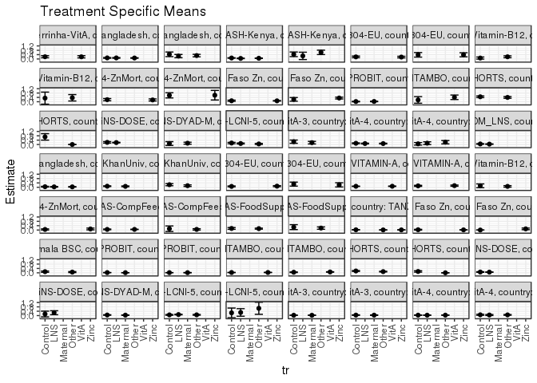

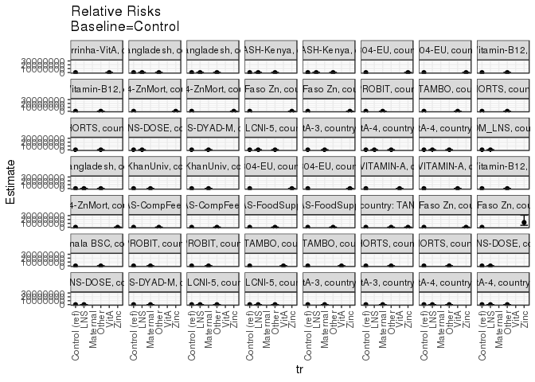

[figure not shown]

[figure not shown]

## Results Table

### Parameter: TSM

| agecat | studyid | country | intXenwast | intervention_level | baseline_level | estimate | ci_lower | ci_upper |
| --- | --- | --- | --- | --- | --- | --- | --- | --- |
| 6 months | iLiNS_DYADM_LNS | MALAWI | 0_6 months | Control | NA | 0.0518293 | 0.0278199 | 0.0758387 |
| 6 months | iLiNS_DYADM_LNS | MALAWI | 0_6 months | LNS | NA | 0.0352564 | 0.0147762 | 0.0557367 |
| 6 months | ki1000110-WASH-Bangladesh | BANGLADESH | 0_6 months | Control | NA | 0.0516129 | 0.0167561 | 0.0864697 |
| 6 months | ki1000110-WASH-Bangladesh | BANGLADESH | 0_6 months | LNS | NA | 0.0388889 | 0.0106241 | 0.0671536 |
| 6 months | ki1000110-WASH-Bangladesh | BANGLADESH | 0_6 months | Other | NA | 0.0379747 | 0.0168846 | 0.0590648 |
| 6 months | ki1000125-AgaKhanUniv | PAKISTAN | 0_6 months | Control | NA | 0.0965517 | 0.0625265 | 0.1305769 |
| 6 months | ki1000125-AgaKhanUniv | PAKISTAN | 0_6 months | Maternal | NA | 0.0833333 | 0.0474233 | 0.1192433 |
| 6 months | ki1000125-AgaKhanUniv | PAKISTAN | 1_6 months | Control | NA | 0.2368421 | 0.1409577 | 0.3327265 |
| 6 months | ki1000125-AgaKhanUniv | PAKISTAN | 1_6 months | Maternal | NA | 0.1445783 | 0.0686820 | 0.2204746 |
| 6 months | ki1000304-EU | INDIA | 0_6 months | Control | NA | 0.0804598 | 0.0399811 | 0.1209384 |
| 6 months | ki1000304-EU | INDIA | 0_6 months | Zinc | NA | 0.1020408 | 0.0530311 | 0.1510505 |
| 6 months | ki1000304-EU | INDIA | 1_6 months | Control | NA | 0.2916667 | 0.1076160 | 0.4757173 |
| 6 months | ki1000304-EU | INDIA | 1_6 months | Zinc | NA | 0.2222222 | 0.0278357 | 0.4166087 |
| 6 months | ki1000304-VITAMIN-A | INDIA | 0_6 months | Control | NA | 0.0905764 | 0.0735576 | 0.1075952 |
| 6 months | ki1000304-VITAMIN-A | INDIA | 0_6 months | VitA | NA | 0.0939535 | 0.0765083 | 0.1113987 |
| 6 months | ki1000304-VITAMIN-A | INDIA | 1_6 months | Control | NA | 0.1279070 | 0.0779206 | 0.1778934 |
| 6 months | ki1000304-VITAMIN-A | INDIA | 1_6 months | VitA | NA | 0.1488095 | 0.0949129 | 0.2027062 |
| 6 months | ki1000304-Vitamin-B12 | INDIA | 0_6 months | Control | NA | 0.1333333 | -0.0398372 | 0.3065039 |
| 6 months | ki1000304-Vitamin-B12 | INDIA | 0_6 months | Other | NA | 0.0819672 | 0.0126712 | 0.1512633 |
| 6 months | ki1000304-ZnMort | INDIA | 0_6 months | Control | NA | 0.0555556 | 0.0024296 | 0.1086815 |
| 6 months | ki1000304-ZnMort | INDIA | 0_6 months | Zinc | NA | 0.0980392 | 0.0160929 | 0.1799855 |
| 6 months | ki1000304b-SAS-CompFeed | INDIA | 0_6 months | Control | NA | 0.0573770 | 0.0238288 | 0.0909253 |
| 6 months | ki1000304b-SAS-CompFeed | INDIA | 0_6 months | Other | NA | 0.0597610 | 0.0407473 | 0.0787746 |
| 6 months | ki1000304b-SAS-CompFeed | INDIA | 1_6 months | Control | NA | 0.1200000 | -0.1375007 | 0.3775007 |
| 6 months | ki1000304b-SAS-CompFeed | INDIA | 1_6 months | Other | NA | 0.0588235 | -0.0031289 | 0.1207759 |
| 6 months | ki1000304b-SAS-FoodSuppl | INDIA | 0_6 months | Control | NA | 0.1466667 | 0.0664633 | 0.2268700 |
| 6 months | ki1000304b-SAS-FoodSuppl | INDIA | 0_6 months | Other | NA | 0.1302326 | 0.0851675 | 0.1752977 |
| 6 months | ki1000304b-SAS-FoodSuppl | INDIA | 1_6 months | Control | NA | 0.2666667 | 0.0411367 | 0.4921966 |
| 6 months | ki1000304b-SAS-FoodSuppl | INDIA | 1_6 months | Other | NA | 0.1800000 | 0.0726819 | 0.2873181 |
| 6 months | ki1066203-TanzaniaChild2 | TANZANIA, UNITED REPUBLIC OF | 0_6 months | Control | NA | 0.0222772 | 0.0078816 | 0.0366729 |

[output cut: 95 more lines]

### Parameter: E(Y)

| agecat | studyid | country | intXenwast | intervention_level | baseline_level | estimate | ci_lower | ci_upper |
| --- | --- | --- | --- | --- | --- | --- | --- | --- |
| 6 months | iLiNS_DYADM_LNS | MALAWI | 0_6 months | NA | NA | 0.0437500 | 0.0278911 | 0.0596089 |
| 6 months | ki1000110-WASH-Bangladesh | BANGLADESH | 0_6 months | NA | NA | 0.0414747 | 0.0261467 | 0.0568026 |
| 6 months | ki1000125-AgaKhanUniv | PAKISTAN | 0_6 months | NA | NA | 0.0907336 | 0.0659746 | 0.1154926 |
| 6 months | ki1000125-AgaKhanUniv | PAKISTAN | 1_6 months | NA | NA | 0.1886792 | 0.1276725 | 0.2496860 |
| 6 months | ki1000304-EU | INDIA | 0_6 months | NA | NA | 0.0903427 | 0.0589334 | 0.1217520 |
| 6 months | ki1000304-EU | INDIA | 1_6 months | NA | NA | 0.2619048 | 0.1273237 | 0.3964859 |
| 6 months | ki1000304-VITAMIN-A | INDIA | 0_6 months | NA | NA | 0.0922509 | 0.0800670 | 0.1044348 |
| 6 months | ki1000304-VITAMIN-A | INDIA | 1_6 months | NA | NA | 0.1382353 | 0.1014942 | 0.1749764 |
| 6 months | ki1000304-Vitamin-B12 | INDIA | 0_6 months | NA | NA | 0.0921053 | 0.0266601 | 0.1575504 |
| 6 months | ki1000304-ZnMort | INDIA | 0_6 months | NA | NA | 0.0731707 | 0.0269606 | 0.1193808 |
| 6 months | ki1000304b-SAS-CompFeed | INDIA | 0_6 months | NA | NA | 0.0585859 | 0.0395002 | 0.0776716 |
| 6 months | ki1000304b-SAS-CompFeed | INDIA | 1_6 months | NA | NA | 0.0847458 | -0.0388078 | 0.2082993 |
| 6 months | ki1000304b-SAS-FoodSuppl | INDIA | 0_6 months | NA | NA | 0.1344828 | 0.0951486 | 0.1738170 |
| 6 months | ki1000304b-SAS-FoodSuppl | INDIA | 1_6 months | NA | NA | 0.2000000 | 0.1020018 | 0.2979982 |
| 6 months | ki1066203-TanzaniaChild2 | TANZANIA, UNITED REPUBLIC OF | 0_6 months | NA | NA | 0.0150470 | 0.0090707 | 0.0210234 |
| 6 months | ki1112895-Burkina Faso Zn | BURKINA FASO | 0_6 months | NA | NA | 0.0162162 | 0.0056986 | 0.0267338 |
| 6 months | ki1112895-Burkina Faso Zn | BURKINA FASO | 1_6 months | NA | NA | 0.0933333 | 0.0270546 | 0.1596121 |
| 6 months | ki1112895-Guatemala BSC | GUATEMALA | 0_6 months | NA | NA | 0.0841121 | 0.0468379 | 0.1213864 |
| 6 months | ki1119695-PROBIT | BELARUS | 0_6 months | NA | NA | 0.0158255 | 0.0094316 | 0.0222194 |
| 6 months | ki1119695-PROBIT | BELARUS | 1_6 months | NA | NA | 0.0153407 | 0.0084618 | 0.0222196 |
| 6 months | ki1126311-ZVITAMBO | ZIMBABWE | 0_6 months | NA | NA | 0.0294923 | 0.0252825 | 0.0337022 |
| 6 months | ki1126311-ZVITAMBO | ZIMBABWE | 1_6 months | NA | NA | 0.0702371 | 0.0553898 | 0.0850843 |
| 6 months | ki1135781-COHORTS | GUATEMALA | 0_6 months | NA | NA | 0.1365576 | 0.1111564 | 0.1619588 |
| 6 months | ki1135781-COHORTS | GUATEMALA | 1_6 months | NA | NA | 0.0705882 | 0.0319716 | 0.1092049 |
| 6 months | ki1148112-iLiNS-DOSE | MALAWI | 0_6 months | NA | NA | 0.0631579 | 0.0522175 | 0.0740983 |
| 6 months | ki1148112-iLiNS-DOSE | MALAWI | 1_6 months | NA | NA | 0.2333333 | 0.0793971 | 0.3872695 |
| 6 months | ki1148112-iLiNS-DYAD-M | MALAWI | 0_6 months | NA | NA | 0.0433884 | 0.0305477 | 0.0562292 |
| 6 months | ki1148112-LCNI-5 | MALAWI | 0_6 months | NA | NA | 0.0800000 | 0.0614765 | 0.0985235 |
| 6 months | ki1148112-LCNI-5 | MALAWI | 1_6 months | NA | NA | 0.3571429 | 0.0966747 | 0.6176110 |
| 6 months | kiGH5241-JiVitA-3 | BANGLADESH | 0_6 months | NA | NA | 0.0274638 | 0.0243176 | 0.0306101 |
| 6 months | kiGH5241-JiVitA-3 | BANGLADESH | 1_6 months | NA | NA | 0.0408029 | 0.0275954 | 0.0540104 |
| 6 months | kiGH5241-JiVitA-4 | BANGLADESH | 0_6 months | NA | NA | 0.0365508 | 0.0305443 | 0.0425574 |
| 6 months | kiGH5241-JiVitA-4 | BANGLADESH | 1_6 months | NA | NA | 0.0620155 | 0.0386564 | 0.0853746 |
| 24 months | ki1000107-Serrinha-VitA | BRAZIL | 0_24 months | NA | NA | 0.2031250 | 0.1331532 | 0.2730968 |
| 24 months | ki1000110-WASH-Bangladesh | BANGLADESH | 0_24 months | NA | NA | 0.0945693 | 0.0770116 | 0.1121270 |
| 24 months | ki1000110-WASH-Bangladesh | BANGLADESH | 1_24 months | NA | NA | 0.3193277 | 0.2352087 | 0.4034468 |
| 24 months | ki1000111-WASH-Kenya | KENYA | 0_24 months | NA | NA | 0.0713963 | 0.0606661 | 0.0821265 |
| 24 months | ki1000111-WASH-Kenya | KENYA | 1_24 months | NA | NA | 0.4901961 | 0.3516323 | 0.6287598 |
| 24 months | ki1000304-EU | INDIA | 0_24 months | NA | NA | 0.1844660 | 0.1313714 | 0.2375606 |
| 24 months | ki1000304-EU | INDIA | 1_24 months | NA | NA | 0.3829787 | 0.2425013 | 0.5234562 |
| 24 months | ki1000304-Vitamin-B12 | INDIA | 0_24 months | NA | NA | 0.1680672 | 0.1006000 | 0.2355344 |
| 24 months | ki1000304-Vitamin-B12 | INDIA | 1_24 months | NA | NA | 0.3571429 | 0.0966747 | 0.6176110 |
| 24 months | ki1000304-ZnMort | INDIA | 0_24 months | NA | NA | 0.1779661 | 0.1086604 | 0.2472718 |
| 24 months | ki1000304-ZnMort | INDIA | 1_24 months | NA | NA | 0.5909091 | 0.3806239 | 0.8011943 |
| 24 months | ki1112895-Burkina Faso Zn | BURKINA FASO | 0_24 months | NA | NA | 0.0852941 | 0.0681442 | 0.1024440 |
| 24 months | ki1112895-Burkina Faso Zn | BURKINA FASO | 1_24 months | NA | NA | 0.3221477 | 0.2468620 | 0.3974333 |
| 24 months | ki1119695-PROBIT | BELARUS | 0_24 months | NA | NA | 0.0225080 | 0.0053216 | 0.0396945 |
| 24 months | ki1126311-ZVITAMBO | ZIMBABWE | 0_24 months | NA | NA | 0.3571429 | 0.1764070 | 0.5378788 |
| 24 months | ki1135781-COHORTS | GUATEMALA | 0_24 months | NA | NA | 0.4267913 | 0.3725990 | 0.4809835 |
| 24 months | ki1135781-COHORTS | GUATEMALA | 1_24 months | NA | NA | 0.5384615 | 0.2564033 | 0.8205198 |
| 24 months | ki1148112-iLiNS-DOSE | MALAWI | 0_24 months | NA | NA | 0.1806283 | 0.1533310 | 0.2079255 |
| 24 months | ki1148112-iLiNS-DYAD-M | MALAWI | 0_24 months | NA | NA | 0.1147541 | 0.0341070 | 0.1954012 |
| 24 months | ki1148112-LCNI-5 | MALAWI | 0_24 months | NA | NA | 0.0954907 | 0.0657849 | 0.1251965 |
| 24 months | kiGH5241-JiVitA-3 | BANGLADESH | 0_24 months | NA | NA | 0.2080000 | 0.1145388 | 0.3014612 |
| 24 months | kiGH5241-JiVitA-4 | BANGLADESH | 0_24 months | NA | NA | 0.0931015 | 0.0732717 | 0.1129314 |
| 24 months | kiGH5241-JiVitA-4 | BANGLADESH | 1_24 months | NA | NA | 0.1472868 | 0.0619909 | 0.2325828 |

### Parameter: RR

| agecat | studyid | country | intXenwast | intervention_level | baseline_level | estimate | ci_lower | ci_upper |
| --- | --- | --- | --- | --- | --- | --- | --- | --- |
| 6 months | iLiNS_DYADM_LNS | MALAWI | 0_6 months | Control | Control | 1.0000000 | 1.0000000 | 1.0000000 |
| 6 months | iLiNS_DYADM_LNS | MALAWI | 0_6 months | LNS | Control | 0.6802413 | 0.3235845 | 1.4300074 |
| 6 months | ki1000110-WASH-Bangladesh | BANGLADESH | 0_6 months | Control | Control | 1.0000000 | 1.0000000 | 1.0000000 |
| 6 months | ki1000110-WASH-Bangladesh | BANGLADESH | 0_6 months | LNS | Control | 0.7534722 | 0.2793732 | 2.0321221 |
| 6 months | ki1000110-WASH-Bangladesh | BANGLADESH | 0_6 months | Other | Control | 0.7357595 | 0.3069008 | 1.7638991 |
| 6 months | ki1000125-AgaKhanUniv | PAKISTAN | 0_6 months | Control | Control | 1.0000000 | 1.0000000 | 1.0000000 |
| 6 months | ki1000125-AgaKhanUniv | PAKISTAN | 0_6 months | Maternal | Control | 0.8630952 | 0.4946528 | 1.5059723 |
| 6 months | ki1000125-AgaKhanUniv | PAKISTAN | 1_6 months | Control | Control | 1.0000000 | 1.0000000 | 1.0000000 |
| 6 months | ki1000125-AgaKhanUniv | PAKISTAN | 1_6 months | Maternal | Control | 0.6104418 | 0.3145856 | 1.1845397 |
| 6 months | ki1000304-EU | INDIA | 0_6 months | Control | Control | 1.0000000 | 1.0000000 | 1.0000000 |
| 6 months | ki1000304-EU | INDIA | 0_6 months | Zinc | Control | 1.2682216 | 0.6325913 | 2.5425355 |
| 6 months | ki1000304-EU | INDIA | 1_6 months | Control | Control | 1.0000000 | 1.0000000 | 1.0000000 |
| 6 months | ki1000304-EU | INDIA | 1_6 months | Zinc | Control | 0.7619048 | 0.2591031 | 2.2404169 |
| 6 months | ki1000304-VITAMIN-A | INDIA | 0_6 months | Control | Control | 1.0000000 | 1.0000000 | 1.0000000 |
| 6 months | ki1000304-VITAMIN-A | INDIA | 0_6 months | VitA | Control | 1.0372845 | 0.7964788 | 1.3508947 |
| 6 months | ki1000304-VITAMIN-A | INDIA | 1_6 months | Control | Control | 1.0000000 | 1.0000000 | 1.0000000 |
| 6 months | ki1000304-VITAMIN-A | INDIA | 1_6 months | VitA | Control | 1.1634199 | 0.6828612 | 1.9821685 |
| 6 months | ki1000304-Vitamin-B12 | INDIA | 0_6 months | Control | Control | 1.0000000 | 1.0000000 | 1.0000000 |
| 6 months | ki1000304-Vitamin-B12 | INDIA | 0_6 months | Other | Control | 0.6147541 | 0.1305204 | 2.8955067 |
| 6 months | ki1000304-ZnMort | INDIA | 0_6 months | Control | Control | 1.0000000 | 1.0000000 | 1.0000000 |
| 6 months | ki1000304-ZnMort | INDIA | 0_6 months | Zinc | Control | 1.7647059 | 0.4955472 | 6.2843392 |
| 6 months | ki1000304b-SAS-CompFeed | INDIA | 0_6 months | Control | Control | 1.0000000 | 1.0000000 | 1.0000000 |
| 6 months | ki1000304b-SAS-CompFeed | INDIA | 0_6 months | Other | Control | 1.0415481 | 0.5345617 | 2.0293682 |
| 6 months | ki1000304b-SAS-CompFeed | INDIA | 1_6 months | Control | Control | 1.0000000 | 1.0000000 | 1.0000000 |
| 6 months | ki1000304b-SAS-CompFeed | INDIA | 1_6 months | Other | Control | 0.4901961 | 0.0466200 | 5.1542748 |
| 6 months | ki1000304b-SAS-FoodSuppl | INDIA | 0_6 months | Control | Control | 1.0000000 | 1.0000000 | 1.0000000 |
| 6 months | ki1000304b-SAS-FoodSuppl | INDIA | 0_6 months | Other | Control | 0.8879493 | 0.4648830 | 1.6960266 |
| 6 months | ki1000304b-SAS-FoodSuppl | INDIA | 1_6 months | Control | Control | 1.0000000 | 1.0000000 | 1.0000000 |
| 6 months | ki1000304b-SAS-FoodSuppl | INDIA | 1_6 months | Other | Control | 0.6750000 | 0.2398340 | 1.8997515 |
| 6 months | ki1066203-TanzaniaChild2 | TANZANIA, UNITED REPUBLIC OF | 0_6 months | Control | Control | 1.0000000 | 1.0000000 | 1.0000000 |

[output cut: 95 more lines]

### Parameter: PAR

| agecat | studyid | country | intXenwast | intervention_level | baseline_level | estimate | ci_lower | ci_upper |
| --- | --- | --- | --- | --- | --- | --- | --- | --- |
| 6 months | iLiNS_DYADM_LNS | MALAWI | 0_6 months | Control | NA | -0.0080793 | -0.0234771 | 0.0073185 |
| 6 months | ki1000110-WASH-Bangladesh | BANGLADESH | 0_6 months | Control | NA | -0.0101382 | -0.0396573 | 0.0193808 |
| 6 months | ki1000125-AgaKhanUniv | PAKISTAN | 0_6 months | Control | NA | -0.0058181 | -0.0275997 | 0.0159635 |
| 6 months | ki1000125-AgaKhanUniv | PAKISTAN | 1_6 months | Control | NA | -0.0481629 | -0.1124013 | 0.0160756 |
| 6 months | ki1000304-EU | INDIA | 0_6 months | Control | NA | 0.0098829 | -0.0192500 | 0.0390158 |
| 6 months | ki1000304-EU | INDIA | 1_6 months | Control | NA | -0.0297619 | -0.1449697 | 0.0854459 |
| 6 months | ki1000304-VITAMIN-A | INDIA | 0_6 months | Control | NA | 0.0016745 | -0.0104103 | 0.0137594 |
| 6 months | ki1000304-VITAMIN-A | INDIA | 1_6 months | Control | NA | 0.0103283 | -0.0260105 | 0.0466672 |
| 6 months | ki1000304-Vitamin-B12 | INDIA | 0_6 months | Control | NA | -0.0412281 | -0.1910070 | 0.1085508 |
| 6 months | ki1000304-ZnMort | INDIA | 0_6 months | Control | NA | 0.0176152 | -0.0230481 | 0.0582785 |
| 6 months | ki1000304b-SAS-CompFeed | INDIA | 0_6 months | Control | NA | 0.0012088 | -0.0184938 | 0.0209114 |
| 6 months | ki1000304b-SAS-CompFeed | INDIA | 1_6 months | Control | NA | -0.0352542 | -0.1851742 | 0.1146657 |
| 6 months | ki1000304b-SAS-FoodSuppl | INDIA | 0_6 months | Control | NA | -0.0121839 | -0.0803936 | 0.0560258 |
| 6 months | ki1000304b-SAS-FoodSuppl | INDIA | 1_6 months | Control | NA | -0.0666667 | -0.2589993 | 0.1256659 |
| 6 months | ki1066203-TanzaniaChild2 | TANZANIA, UNITED REPUBLIC OF | 0_6 months | Control | NA | -0.0072302 | -0.0189763 | 0.0045159 |
| 6 months | ki1112895-Burkina Faso Zn | BURKINA FASO | 0_6 months | Control | NA | -0.0119528 | -0.0468068 | 0.0229012 |
| 6 months | ki1112895-Burkina Faso Zn | BURKINA FASO | 1_6 months | Control | NA | 0.0933333 | 0.0270546 | 0.1596121 |
| 6 months | ki1112895-Guatemala BSC | GUATEMALA | 0_6 months | Control | NA | -0.0196614 | -0.0573578 | 0.0180349 |
| 6 months | ki1119695-PROBIT | BELARUS | 0_6 months | Control | NA | -0.0039500 | -0.0102692 | 0.0023692 |
| 6 months | ki1119695-PROBIT | BELARUS | 1_6 months | Control | NA | -0.0014153 | -0.0079604 | 0.0051298 |
| 6 months | ki1126311-ZVITAMBO | ZIMBABWE | 0_6 months | Control | NA | 0.0019333 | -0.0052846 | 0.0091512 |
| 6 months | ki1126311-ZVITAMBO | ZIMBABWE | 1_6 months | Control | NA | 0.0183339 | -0.0049661 | 0.0416340 |
| 6 months | ki1135781-COHORTS | GUATEMALA | 0_6 months | Control | NA | -0.0301091 | -0.0568549 | -0.0033632 |
| 6 months | ki1135781-COHORTS | GUATEMALA | 1_6 months | Control | NA | -0.0518607 | -0.0808992 | -0.0228222 |
| 6 months | ki1148112-iLiNS-DOSE | MALAWI | 0_6 months | Control | NA | -0.0071296 | -0.0327761 | 0.0185169 |
| 6 months | ki1148112-iLiNS-DOSE | MALAWI | 1_6 months | Control | NA | 0.0904762 | -0.1560413 | 0.3369936 |
| 6 months | ki1148112-iLiNS-DYAD-M | MALAWI | 0_6 months | Control | NA | -0.0084408 | -0.0271647 | 0.0102831 |
| 6 months | ki1148112-LCNI-5 | MALAWI | 0_6 months | Control | NA | 0.0165854 | -0.0134754 | 0.0466462 |
| 6 months | ki1148112-LCNI-5 | MALAWI | 1_6 months | Control | NA | 0.1071429 | -0.2813827 | 0.4956685 |
| 6 months | kiGH5241-JiVitA-3 | BANGLADESH | 0_6 months | Control | NA | -0.0009439 | -0.0041608 | 0.0022730 |
| 6 months | kiGH5241-JiVitA-3 | BANGLADESH | 1_6 months | Control | NA | -0.0029270 | -0.0157468 | 0.0098928 |
| 6 months | kiGH5241-JiVitA-4 | BANGLADESH | 0_6 months | Control | NA | -0.0008876 | -0.0115209 | 0.0097457 |
| 6 months | kiGH5241-JiVitA-4 | BANGLADESH | 1_6 months | Control | NA | -0.0083363 | -0.0488039 | 0.0321314 |
| 24 months | ki1000107-Serrinha-VitA | BRAZIL | 0_24 months | Control | NA | -0.0027574 | -0.0684403 | 0.0629256 |
| 24 months | ki1000110-WASH-Bangladesh | BANGLADESH | 0_24 months | Control | NA | -0.0054307 | -0.0377487 | 0.0268873 |
| 24 months | ki1000110-WASH-Bangladesh | BANGLADESH | 1_24 months | Control | NA | -0.1092437 | -0.2997925 | 0.0813051 |
| 24 months | ki1000111-WASH-Kenya | KENYA | 0_24 months | Control | NA | -0.0192668 | -0.0353147 | -0.0032188 |
| 24 months | ki1000111-WASH-Kenya | KENYA | 1_24 months | Control | NA | 0.0616246 | -0.1034923 | 0.2267416 |
| 24 months | ki1000304-EU | INDIA | 0_24 months | Control | NA | -0.0078417 | -0.0604065 | 0.0447232 |
| 24 months | ki1000304-EU | INDIA | 1_24 months | Control | NA | 0.0020263 | -0.1542521 | 0.1583048 |
| 24 months | ki1000304-Vitamin-B12 | INDIA | 0_24 months | Control | NA | 0.0823529 | -0.0077778 | 0.1724836 |
| 24 months | ki1000304-Vitamin-B12 | INDIA | 1_24 months | Control | NA | 0.0238095 | -0.4690930 | 0.5167120 |
| 24 months | ki1000304-ZnMort | INDIA | 0_24 months | Control | NA | -0.0116891 | -0.0822389 | 0.0588607 |
| 24 months | ki1000304-ZnMort | INDIA | 1_24 months | Control | NA | 0.0026738 | -0.1110979 | 0.1164455 |
| 24 months | ki1112895-Burkina Faso Zn | BURKINA FASO | 0_24 months | Control | NA | -0.0065426 | -0.0607438 | 0.0476585 |
| 24 months | ki1112895-Burkina Faso Zn | BURKINA FASO | 1_24 months | Control | NA | 0.1047563 | -0.0547541 | 0.2642668 |
| 24 months | ki1119695-PROBIT | BELARUS | 0_24 months | Control | NA | 0.0041257 | -0.0155407 | 0.0237920 |
| 24 months | ki1126311-ZVITAMBO | ZIMBABWE | 0_24 months | Control | NA | 0.1904762 | -0.1016888 | 0.4826412 |
| 24 months | ki1135781-COHORTS | GUATEMALA | 0_24 months | Control | NA | -0.0294587 | -0.0838224 | 0.0249050 |
| 24 months | ki1135781-COHORTS | GUATEMALA | 1_24 months | Control | NA | -0.1615385 | -0.3418132 | 0.0187362 |
| 24 months | ki1148112-iLiNS-DOSE | MALAWI | 0_24 months | Control | NA | -0.0162221 | -0.0790044 | 0.0465601 |
| 24 months | ki1148112-iLiNS-DYAD-M | MALAWI | 0_24 months | Control | NA | 0.0238450 | -0.1351012 | 0.1827912 |
| 24 months | ki1148112-LCNI-5 | MALAWI | 0_24 months | Control | NA | -0.0408729 | -0.0918605 | 0.0101146 |
| 24 months | kiGH5241-JiVitA-3 | BANGLADESH | 0_24 months | Control | NA | -0.0512593 | -0.1604185 | 0.0579000 |
| 24 months | kiGH5241-JiVitA-4 | BANGLADESH | 0_24 months | Control | NA | -0.0194526 | -0.0537617 | 0.0148565 |
| 24 months | kiGH5241-JiVitA-4 | BANGLADESH | 1_24 months | Control | NA | 0.0827707 | -0.0371198 | 0.2026611 |

### Parameter: PAF

| agecat | studyid | country | intXenwast | intervention_level | baseline_level | estimate | ci_lower | ci_upper |
| --- | --- | --- | --- | --- | --- | --- | --- | --- |
| 6 months | iLiNS_DYADM_LNS | MALAWI | 0_6 months | Control | NA | -0.1846690 | -0.5868013 | 0.1155537 |
| 6 months | ki1000110-WASH-Bangladesh | BANGLADESH | 0_6 months | Control | NA | -0.2444444 | -1.1956871 | 0.2946891 |
| 6 months | ki1000125-AgaKhanUniv | PAKISTAN | 0_6 months | Control | NA | -0.0641233 | -0.3327893 | 0.1503846 |
| 6 months | ki1000125-AgaKhanUniv | PAKISTAN | 1_6 months | Control | NA | -0.2552632 | -0.6408874 | 0.0397357 |
| 6 months | ki1000304-EU | INDIA | 0_6 months | Control | NA | 0.1093936 | -0.2765343 | 0.3786459 |
| 6 months | ki1000304-EU | INDIA | 1_6 months | Control | NA | -0.1136364 | -0.6518542 | 0.2492159 |
| 6 months | ki1000304-VITAMIN-A | INDIA | 0_6 months | Control | NA | 0.0181519 | -0.1219686 | 0.1407730 |
| 6 months | ki1000304-VITAMIN-A | INDIA | 1_6 months | Control | NA | 0.0747155 | -0.2286047 | 0.3031514 |
| 6 months | ki1000304-Vitamin-B12 | INDIA | 0_6 months | Control | NA | -0.4476190 | -3.3840944 | 0.5219991 |
| 6 months | ki1000304-ZnMort | INDIA | 0_6 months | Control | NA | 0.2407407 | -0.5403496 | 0.6257508 |
| 6 months | ki1000304b-SAS-CompFeed | INDIA | 0_6 months | Control | NA | 0.0206331 | -0.3854080 | 0.3076700 |
| 6 months | ki1000304b-SAS-CompFeed | INDIA | 1_6 months | Control | NA | -0.4160000 | -2.6932968 | 0.4571094 |
| 6 months | ki1000304b-SAS-FoodSuppl | INDIA | 0_6 months | Control | NA | -0.0905983 | -0.7356340 | 0.3147146 |
| 6 months | ki1000304b-SAS-FoodSuppl | INDIA | 1_6 months | Control | NA | -0.3333333 | -1.7331461 | 0.3495490 |
| 6 months | ki1066203-TanzaniaChild2 | TANZANIA, UNITED REPUBLIC OF | 0_6 months | Control | NA | -0.4805074 | -1.4704185 | 0.1127405 |
| 6 months | ki1112895-Burkina Faso Zn | BURKINA FASO | 0_6 months | Control | NA | -0.7370892 | -4.8143526 | 0.4810293 |
| 6 months | ki1112895-Burkina Faso Zn | BURKINA FASO | 1_6 months | Control | NA | 0.9999999 | 0.9999998 | 1.0000000 |
| 6 months | ki1112895-Guatemala BSC | GUATEMALA | 0_6 months | Control | NA | -0.2337526 | -0.7607378 | 0.1355070 |
| 6 months | ki1119695-PROBIT | BELARUS | 0_6 months | Control | NA | -0.2495991 | -0.6455156 | 0.0510585 |
| 6 months | ki1119695-PROBIT | BELARUS | 1_6 months | Control | NA | -0.0922595 | -0.6496860 | 0.2768134 |
| 6 months | ki1126311-ZVITAMBO | ZIMBABWE | 0_6 months | Control | NA | 0.0655523 | -0.2140059 | 0.2807345 |
| 6 months | ki1126311-ZVITAMBO | ZIMBABWE | 1_6 months | Control | NA | 0.2610294 | -0.1512709 | 0.5256742 |
| 6 months | ki1135781-COHORTS | GUATEMALA | 0_6 months | Control | NA | -0.2204861 | -0.4298216 | -0.0417987 |
| 6 months | ki1135781-COHORTS | GUATEMALA | 1_6 months | Control | NA | -0.7346939 | -0.9739949 | -0.5244025 |
| 6 months | ki1148112-iLiNS-DOSE | MALAWI | 0_6 months | Control | NA | -0.1128860 | -0.6023586 | 0.2270673 |
| 6 months | ki1148112-iLiNS-DOSE | MALAWI | 1_6 months | Control | NA | 0.3877551 | -2.3299886 | 0.8874339 |
| 6 months | ki1148112-iLiNS-DYAD-M | MALAWI | 0_6 months | Control | NA | -0.1945412 | -0.7094045 | 0.1652481 |
| 6 months | ki1148112-LCNI-5 | MALAWI | 0_6 months | Control | NA | 0.2073171 | -0.2691624 | 0.5049127 |
| 6 months | ki1148112-LCNI-5 | MALAWI | 1_6 months | Control | NA | 0.3000000 | -2.2884850 | 0.8509952 |
| 6 months | kiGH5241-JiVitA-3 | BANGLADESH | 0_6 months | Control | NA | -0.0343678 | -0.1581626 | 0.0761946 |
| 6 months | kiGH5241-JiVitA-3 | BANGLADESH | 1_6 months | Control | NA | -0.0717353 | -0.4306089 | 0.1971135 |
| 6 months | kiGH5241-JiVitA-4 | BANGLADESH | 0_6 months | Control | NA | -0.0242836 | -0.3602642 | 0.2287109 |
| 6 months | kiGH5241-JiVitA-4 | BANGLADESH | 1_6 months | Control | NA | -0.1344221 | -1.0170229 | 0.3619738 |
| 24 months | ki1000107-Serrinha-VitA | BRAZIL | 0_24 months | Control | NA | -0.0135747 | -0.3944479 | 0.2632686 |
| 24 months | ki1000110-WASH-Bangladesh | BANGLADESH | 0_24 months | Control | NA | -0.0574257 | -0.4606691 | 0.2344952 |
| 24 months | ki1000110-WASH-Bangladesh | BANGLADESH | 1_24 months | Control | NA | -0.3421053 | -1.0962834 | 0.1407428 |
| 24 months | ki1000111-WASH-Kenya | KENYA | 0_24 months | Control | NA | -0.2698566 | -0.5122167 | -0.0663392 |
| 24 months | ki1000111-WASH-Kenya | KENYA | 1_24 months | Control | NA | 0.1257143 | -0.2870887 | 0.4061206 |
| 24 months | ki1000304-EU | INDIA | 0_24 months | Control | NA | -0.0425101 | -0.3700338 | 0.2067149 |
| 24 months | ki1000304-EU | INDIA | 1_24 months | Control | NA | 0.0052910 | -0.4991929 | 0.3400142 |
| 24 months | ki1000304-Vitamin-B12 | INDIA | 0_24 months | Control | NA | 0.4900000 | -0.3777300 | 0.8112112 |
| 24 months | ki1000304-Vitamin-B12 | INDIA | 1_24 months | Control | NA | 0.0666667 | -3.0949261 | 0.7872706 |
| 24 months | ki1000304-ZnMort | INDIA | 0_24 months | Control | NA | -0.0656814 | -0.5452520 | 0.2650539 |
| 24 months | ki1000304-ZnMort | INDIA | 1_24 months | Control | NA | 0.0045249 | -0.2079073 | 0.1795971 |
| 24 months | ki1112895-Burkina Faso Zn | BURKINA FASO | 0_24 months | Control | NA | -0.0767065 | -0.9424661 | 0.4031829 |
| 24 months | ki1112895-Burkina Faso Zn | BURKINA FASO | 1_24 months | Control | NA | 0.3251812 | -0.4012035 | 0.6750076 |
| 24 months | ki1119695-PROBIT | BELARUS | 0_24 months | Control | NA | 0.1832983 | -1.4187756 | 0.7242400 |
| 24 months | ki1126311-ZVITAMBO | ZIMBABWE | 0_24 months | Control | NA | 0.5333333 | -1.5710002 | 0.9152945 |
| 24 months | ki1135781-COHORTS | GUATEMALA | 0_24 months | Control | NA | -0.0690237 | -0.2045018 | 0.0512163 |
| 24 months | ki1135781-COHORTS | GUATEMALA | 1_24 months | Control | NA | -0.3000000 | -0.7722710 | 0.0464212 |
| 24 months | ki1148112-iLiNS-DOSE | MALAWI | 0_24 months | Control | NA | -0.0898094 | -0.4990182 | 0.2076917 |
| 24 months | ki1148112-iLiNS-DYAD-M | MALAWI | 0_24 months | Control | NA | 0.2077921 | -3.5165017 | 0.8610444 |
| 24 months | ki1148112-LCNI-5 | MALAWI | 0_24 months | Control | NA | -0.4280303 | -1.0585335 | 0.0093576 |
| 24 months | kiGH5241-JiVitA-3 | BANGLADESH | 0_24 months | Control | NA | -0.2464387 | -0.8977126 | 0.1813252 |
| 24 months | kiGH5241-JiVitA-4 | BANGLADESH | 0_24 months | Control | NA | -0.2089397 | -0.6415493 | 0.1096612 |
| 24 months | kiGH5241-JiVitA-4 | BANGLADESH | 1_24 months | Control | NA | 0.5619694 | -1.4206014 | 0.9207343 |